# EDA-Assignment-IV (Healthcare Fraud Detection)

Ram Subramanian (RS3955)

October 6, 2019

## Feature Engineering for Healthcare Fraud Detection

#### We will use the following data sourced from the variables in the Inpatient charges data by Medicare Severity Diagnosis Related Group (DRG) to create insightful features:

#### a. Ratio of discharges between DRG-Provider combination and total discharges at a State, Zip code and HRR level

#### b. Differences and deviations of charges and payments related to every DRG at a State, Zip and HRR level relative to the mean values of the respective groups

```r
#LOAD LIBRARIES AND IMPORT Inpatient Charges DATA
library(sqldf)
library(dplyr)
```

```r
library(plotly)
library(ggplot2)
library(data.table)
library(zipcode)
library(tidyverse)
library(stringr)
library(ggthemes)
library(maps)
library(rgeos)
library(sp)
library(maptools)
setwd('C:/myfiles/Anomaly/assignment4')
payment=read.csv('inpatientCharges.csv')
```

```r
str(payment)
```

```
## 'data.frame':    163065 obs. of  12 variables:
##  $ DRG.Definition                      : Factor w/ 100 levels "039 - EXTRACRANIAL PROCEDURES W/O CC/MCC",..: 1 1 1 1 1 1 1 1 1 1 ...
##  $ Provider.Id                         : int  10001 10005 10006 10011 10016 10023 10029 10033 10039 10040 ...
##  $ Provider.Name                       : Factor w/ 3201 levels "ABBEVILLE GENERAL HOSPITAL",..: 2519 1499 730 2714 2445 158 687 2960 1133 882 ...
##  $ Provider.Street.Address             : Factor w/ 3326 levels "#1 MEDICAL PARK DRIVE",..: 319 1494 1230 2291 87 1266 1165 2632 168 143 ...
##  $ Provider.City                       : Factor w/ 1977 levels "ABBEVILLE","ABERDEEN",..: 455 178 583 163 14 1152 1293 163 811 631 ...
##  $ Provider.State                      : Factor w/ 51 levels "AK","AL","AR",..: 2 2 2 2 2 2 2 2 2 2 ...
##  $ Provider.Zip.Code                   : int  36301 35957 35631 35235 35007 36116 36801 35233 35801 35903 ...
##  $ Hospital.Referral.Region.Description: Factor w/ 306 levels "AK - Anchorage",..: 3 2 2 2 2 6 2 2 4 2 ...
##  $ Total.Discharges                    : int  91 14 24 25 18 67 51 32 135 34 ...
##  $ Average.Covered.Charges             : Factor w/ 160236 levels "$10000.36","$10000.64",..: 97796 29994 107397 23460 94605 39942 11502 104040 86419 145812 ...
##  $ Average.Total.Payments              : Factor w/ 147842 levels "$10000.05","$10000.07",..: 93930 94141 87284 86948 91606 110289 95031 129770 100393 89333 ...
##  $ Average.Medicare.Payments           : Factor w/ 150328 levels "$10000.09","$10000.35",..: 86548 90839 80274 73754 88332 98755 86502 107455 95873 78913 ...
```

```r
#Checking for NA in dataset
indx <- apply(payment, 2, function(x) any(is.na(x)))
indx
```

```
##                       DRG.Definition                          Provider.Id
##                                FALSE                                FALSE
##                        Provider.Name              Provider.Street.Address
##                                FALSE                                FALSE
##                        Provider.City                       Provider.State
##                                FALSE                                FALSE
##                    Provider.Zip.Code Hospital.Referral.Region.Description
##                                FALSE                                FALSE
##                     Total.Discharges              Average.Covered.Charges
##                                FALSE                                FALSE
##               Average.Total.Payments            Average.Medicare.Payments
##                                FALSE                                FALSE
```

```r
# Convert the Charges to numeric
p1 <- strsplit(x = as.character(payment$Average.Covered.Charges),split = "$",fixed = T)
payment$Average.Covered.Charges <- as.numeric(sapply(p1,"[[",2))
p1 <- strsplit(x = as.character(payment$Average.Total.Payments),split = "$",fixed = T)
payment$Average.Total.Payments <- as.numeric(sapply(p1,"[[",2))
p1 <- strsplit(x = as.character(payment$Average.Medicare.Payments),split = "$",fixed = T)
payment$Average.Medicare.Payments <- as.numeric(sapply(p1,"[[",2))
rm("p1")
```

#### EXPLORATORY DATA ANALYSIS

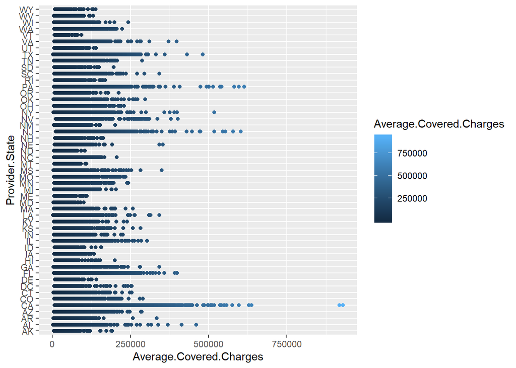

```r
payment <- as.data.table(payment)
#Average Covered Charges by State
av1 <- payment[,Average.Covered.Charges,by=Provider.State]
ggplot(data = av1,mapping = aes(y = Provider.State,x = Average.Covered.Charges,colour=Average.Covered.Charges))+
  geom_point()
```

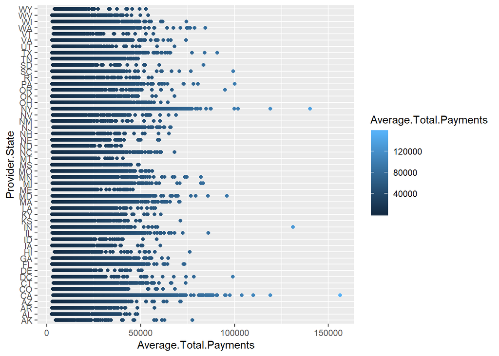

```r
#Average Total Payments by State
av1 <- payment[,Average.Total.Payments,by=Provider.State]
ggplot(data = av1,mapping = aes(y = Provider.State,x = Average.Total.Payments,colour=Average.Total.Payments))+
  geom_point()
```

```r
#Create variables for Latitude & Longitude

payment$Provider.Zip.Code<-as.factor(payment$Provider.Zip.Code)
data(zipcode)
payment=merge(payment,zipcode,by.x='Provider.Zip.Code',by.y='zip')
```

#### FEATURE ENGINEERING

##### In order to aggregate Inpatient charges across different combinations of DRG with State, Zipcode and Hospital Referral Region (HRR) respectively we create unique IDs for each of the combinations as follows.

```r
# create unique ID based on DRG and State combination
payment <- mutate(payment, DRGbyState = group_indices(payment, DRG.Definition,Provider.State))

# create unique ID based on DRG and Zipcode combination
payment <- mutate(payment, DRGbyZip = group_indices(payment, DRG.Definition,Provider.Zip.Code))

# create unique ID based on DRG and Hospital Referral Region combination
payment <- mutate(payment, DRGbyHRR = group_indices(payment, DRG.Definition,Hospital.Referral.Region.Description))

head(payment)
```

```
##   Provider.Zip.Code
## 1             10003
## 2             10003
## 3             10003
## 4             10003
## 5             10003
## 6             10003
##                                                    DRG.Definition
## 1                        039 - EXTRACRANIAL PROCEDURES W/O CC/MCC
## 2             057 - DEGENERATIVE NERVOUS SYSTEM DISORDERS W/O MCC
## 3      064 - INTRACRANIAL HEMORRHAGE OR CEREBRAL INFARCTION W MCC
## 4       065 - INTRACRANIAL HEMORRHAGE OR CEREBRAL INFARCTION W CC
## 5 066 - INTRACRANIAL HEMORRHAGE OR CEREBRAL INFARCTION W/O CC/MCC
## 6                                        069 - TRANSIENT ISCHEMIA
##   Provider.Id              Provider.Name     Provider.Street.Address
```

[output cut: 34 more lines]

#### 1 - Difference between ‘Provider’s charges for medicare-covered services’ and ‘Amount that Medicare paid to the provider’

##### This feature will provide the difference between what the Provider claimed and what he was paid by Medicare, which can be used to determine the providers who have a tendency to claim reimburement in excess.

```r
payment$ChargePayDiff <- payment$Average.Covered.Charges - payment$Average.Medicare.Payments
```

#### 2 - Difference between Mean Provider’s Average Covered Charges and Excess Provider’s charges over Medicare Payments’ (from Feature 1) for every DRG at a state level

```r
MeanChargePayDiff_State <- sqldf('select DRGbyState, avg(ChargePayDiff) as MeanChargePayDiff_State from payment group by DRGbyState')
payment <- merge(payment, MeanChargePayDiff_State)
payment$ChargePayDiff_State <- payment$ChargePayDiff - payment$MeanChargePayDiff_State
```

##### The above feature contains both +ve & -ve values; we’re interested only in +ve values higher than a specific set limit, say top 40% (since only positive values indicate charged in excess). The following plot shows some outlying points which are DRG-State combos where the average amount Providers charge are usually way higher than what the Medicare finally pays to provider for the DRG on an average in the respective States.

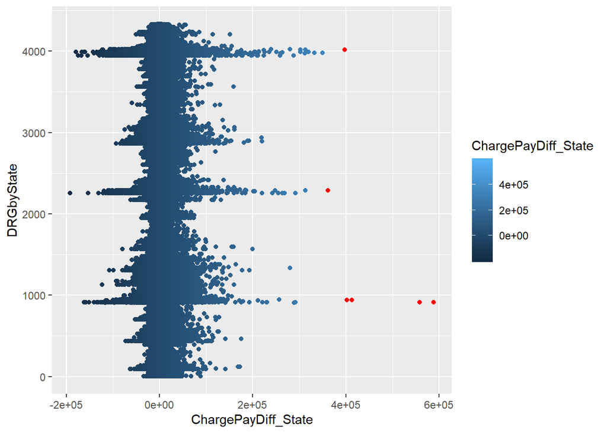

```r
payment <- as.data.table(payment)
df_outlier <- payment[payment$ChargePayDiff_State > 0.6*(max(payment$ChargePayDiff_State) - min(payment$ChargePayDiff_State[payment$ChargePayDiff_State> 0])),]
av1 <- payment[,ChargePayDiff_State,by=DRGbyState]
ggplot(data = av1,mapping = aes(y = DRGbyState,x = ChargePayDiff_State,colour=ChargePayDiff_State))+
  geom_point() +
  geom_point(data=df_outlier, aes(x=ChargePayDiff_State,y=DRGbyState), color='red',size=1.5)
```

#### 3 - Difference between Mean Provider’s Average Covered Charges and Excess Provider’s charges over Medicare Payments’ (from Feature 1) for every DRG at a Zipcode level

```r
MeanChargePayDiff_Zip <- sqldf('select DRGbyZip, avg(ChargePayDiff) as MeanChargePayDiff_Zip from payment group by DRGbyZip')
payment <- merge(payment, MeanChargePayDiff_Zip)
payment$ChargePayDiff_Zip <- payment$ChargePayDiff - payment$MeanChargePayDiff_Zip
```

##### The above feature contains both +ve & -ve values; we’re interested only in +ve values higher than a specific set limit, say top 40% (since only positive values indicate charged in excess). These outlying values would be DRG-Zipcode combos where the average amount Providers charge are usually way higher than what the Medicare finally pays to provider for the DRG on an average in the respective Zipcodes

#### 4 - Difference between Mean Provider’s Average Covered Charges and Excess Provider’s charges over Medicare Payments’ (from Feature 1) for every DRG at a Hospital Referral Region (HRR) level

```r
MeanChargePayDiff_HRR <- sqldf('select DRGbyHRR, avg(ChargePayDiff) as MeanChargePayDiff_HRR from payment group by DRGbyHRR')
payment <- as.data.frame(payment)
payment <- merge(payment,MeanChargePayDiff_HRR)
payment$ChargePayDiff_HRR <- payment$ChargePayDiff - payment$MeanChargePayDiff_HRR
```

##### The above feature contains both +ve & -ve values; we’re interested only in +ve values higher than a specific set limit, say top 40% (since only positive values indicate charged in excess). The following plot shows some outlying points which are DRG-HRR combos where the average amount Providers charge are usually way higher than what the Medicare finally pays to provider for the DRG on an average in the respective HRRs.

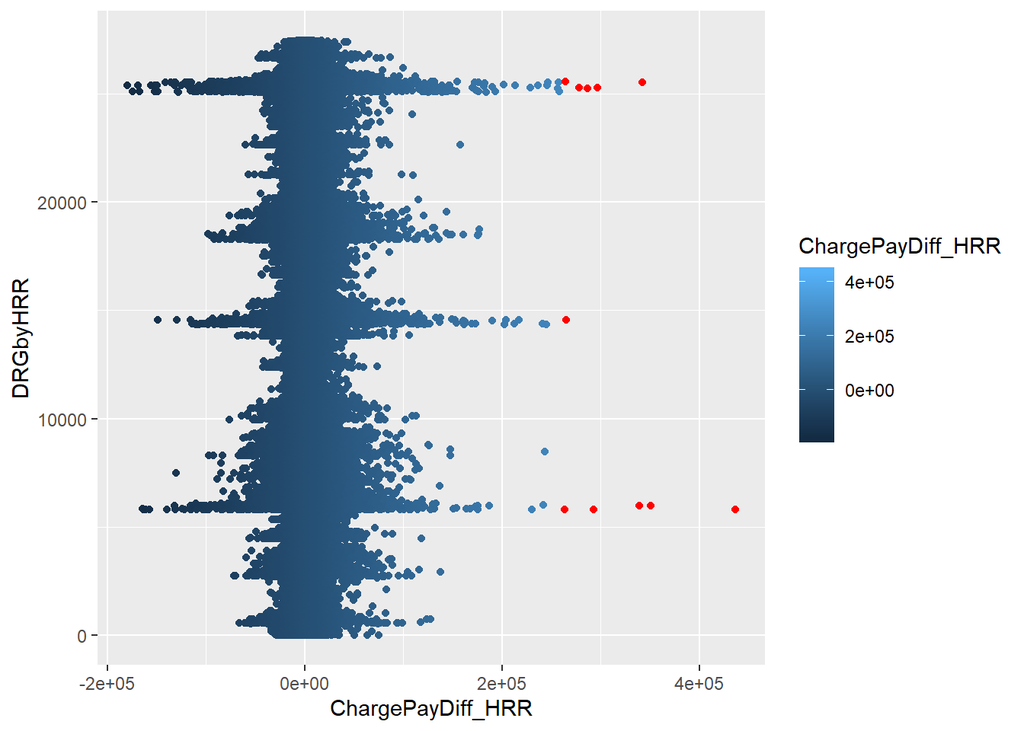

```r
payment <- as.data.table(payment)
df_outlier <- payment[payment$ChargePayDiff_HRR > 0.6*(max(payment$ChargePayDiff_HRR) - min(payment$ChargePayDiff_HRR[payment$ChargePayDiff_HRR> 0])),]
av1 <- payment[,ChargePayDiff_HRR,by=DRGbyHRR]
ggplot(data = av1,mapping = aes(y = DRGbyHRR,x = ChargePayDiff_HRR,colour=ChargePayDiff_HRR))+
  geom_point() +
  geom_point(data=df_outlier, aes(x=ChargePayDiff_HRR,y=DRGbyHRR), color='red',size=1.5)
```

#### 5 - Difference between Total payment to the provider for a DRG and the mean of the Total payment to the Provider with DRGs grouped by State

```r
payment <- as.data.frame(payment)
MeanTotalPmt_State <- sqldf('select DRGbyState, avg("Average.Total.Payments") as MeanTotalPmt_State from payment group by DRGbyState')
payment <- merge(payment, MeanTotalPmt_State)
payment$TotalPmtDiff_State <- payment$Average.Total.Payments - payment$MeanTotalPmt_State
```

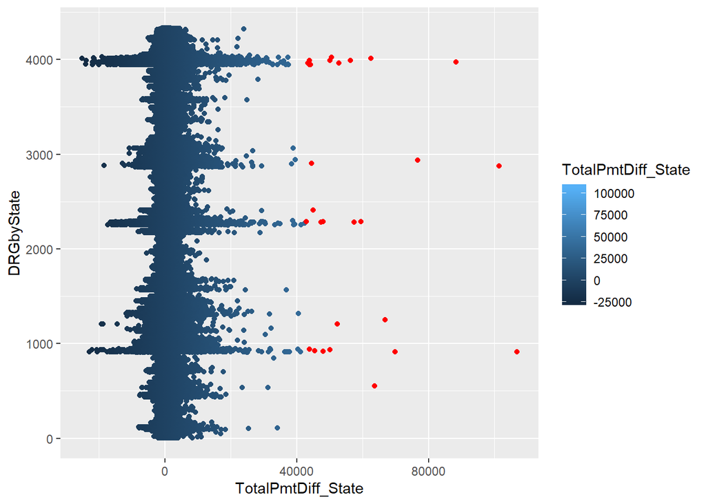

```r
payment <- as.data.table(payment)
df_outlier <- payment[payment$TotalPmtDiff_State > 0.4*(max(payment$TotalPmtDiff_State) - min(payment$TotalPmtDiff_State[payment$TotalPmtDiff_State> 0])),]
av1 <- payment[,TotalPmtDiff_State,by=DRGbyState]
ggplot(data = av1,mapping = aes(y = DRGbyState,x = TotalPmtDiff_State,colour=TotalPmtDiff_State))+
  geom_point() +
  geom_point(data=df_outlier, aes(x=TotalPmtDiff_State,y=DRGbyState), color='red',size=1.5)
```

#### 6 - Difference between Total payment to the provider for a DRG and the mean of the Total payment to the Provider with DRGs grouped by Zipcode

```r
payment <- as.data.frame(payment)
MeanTotalPmt_Zip <- sqldf('select DRGbyZip, avg("Average.Total.Payments") as MeanTotalPmt_Zip from payment group by DRGbyZip')
payment <- merge(payment, MeanTotalPmt_Zip)
payment$TotalPmtDiff_Zip <- payment$Average.Total.Payments - payment$MeanTotalPmt_Zip
```

##### The above feature contains both +ve & -ve values; we’re interested only in +ve values higher than a specific set limit, say top 40% (since only positive values indicate charged in excess). These outlying values would be the DRG-Zipcode combos where the Total payments to the provider are way higher than the mean of the Total payment to the Provider grouped by DRG-Zipcode combination

#### 7 - Difference between Total payment to the provider for a DRG and the mean of the Total payment to the Provider with DRGs grouped by Hospital Referral Regions (HRRs)

```r
payment <- as.data.frame(payment)
MeanTotalPmt_HRR <- sqldf('select DRGbyHRR, avg("Average.Total.Payments") as MeanTotalPmt_HRR from payment group by DRGbyHRR')
payment <- merge(payment, MeanTotalPmt_HRR)
payment$TotalPmtDiff_HRR <- payment$Average.Total.Payments - payment$MeanTotalPmt_HRR
```

##### The above feature contains both +ve & -ve values; we’re interested only in +ve values higher than a specific set limit, say top 40% (since only positive values indicate charged in excess). These outlying values would be the DRG-HRR combos where the Total payments to the provider are way higher than the mean of the Total payment to the Provider grouped by DRG-HRR combination

#### 8 - Ratio of total discharges for a DRG at a Provider level over total discharges for a DRG at a state level

```r
payment <- as.data.frame(payment)
TotalDschrg_State <- sqldf('select DRGbyState, sum("Total.Discharges") as TotalDschrg_State from payment group by DRGbyState')
payment <- merge(payment, TotalDschrg_State)
payment$DschrgRatio_State <- payment$Total.Discharges/payment$TotalDschrg_State
```

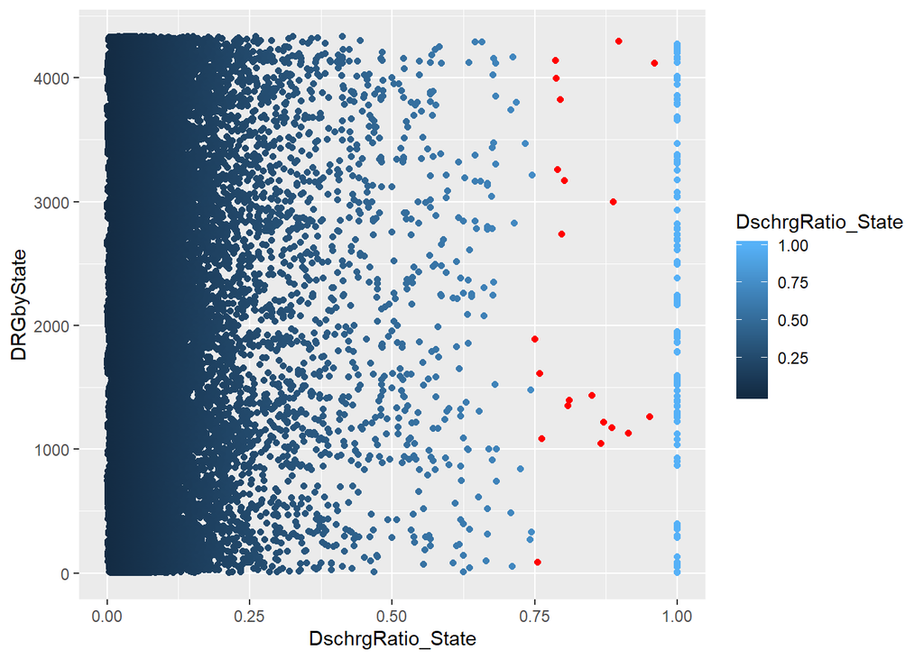

```r
payment <- as.data.table(payment)
df_outlier <- payment[(payment$DschrgRatio_State > 0.75*(max(payment$DschrgRatio_State) - min(payment$DschrgRatio_State[payment$DschrgRatio_State> 0]))) & (payment$DschrgRatio_State < 1),]
av1 <- payment[,DschrgRatio_State,by=DRGbyState]
ggplot(data = av1,mapping = aes(y = DRGbyState,x = DschrgRatio_State,colour=DschrgRatio_State))+
  geom_point() +
  geom_point(data=df_outlier, aes(x=DschrgRatio_State,y=DRGbyState), color='red',size=1.5)
```

#### 9 - Ratio of total discharges for a DRG at a Provider level over total discharges for a DRG at a Zip code level

```r
payment <- as.data.frame(payment)
TotalDschrg_Zip <- sqldf('select DRGbyZip, sum("Total.Discharges") as TotalDschrg_Zip from payment group by DRGbyZip')
payment <- merge(payment, TotalDschrg_Zip)
payment$DschrgRatio_Zip <- payment$Total.Discharges/payment$TotalDschrg_Zip
```

##### In this feature representing Ratio of total discharges for a DRG at a Provider level over total discharges for a DRG at a Zip code level, we’re interested in outlier values higher than a specific set limit, say top 10% with high ratios as they may indicate patients from those regions in the Zip code with a specific DRGs are potentially targeted by provider groups for overcharging.

#### 10 - Ratio of total discharges for a DRG at a Provider level over total discharges for a DRG at a HRR level

```r
payment <- as.data.frame(payment)
TotalDschrg_HRR <- sqldf('select DRGbyHRR, sum("Total.Discharges") as TotalDschrg_HRR from payment group by DRGbyHRR')
payment <- merge(payment, TotalDschrg_HRR)
payment$DschrgRatio_HRR <- payment$Total.Discharges/payment$TotalDschrg_HRR
```

##### In this feature representing Ratio of total discharges for a DRG at a Provider level over total discharges for a DRG at a HRR level, we’re interested in values higher than a specific set limit, say top 10% with high ratios as they may indicate patients from those regions in the HRR with a specific DRGs are potentially targeted by provider groups for overcharging.

#### 11 - Standard deviation between Total payment to the provider for a DRG and the mean of the Total payment to the Provider grouped by DRG-State combination

```r
payment <- as.data.frame(payment)
SDTotalPmt_State <- sqldf('select DRGbyState, stdev("Average.Total.Payments") as SDTotalPmt_State from payment group by DRGbyState')
payment <- merge(payment, SDTotalPmt_State)
payment$SDTotalPmt_State[is.na(payment$SDTotalPmt_State)] <- 0 #replacing NAs for single entries with 0s for SD
payment$SDTotalPmtDiff_State <- (payment$TotalPmtDiff_State/payment$SDTotalPmt_State)

#Replacing all NAs for single entries and negative values to 0s for SD as we are interested only in amount higher, not lesser than the mean
payment$SDTotalPmtDiff_State[is.na(payment$SDTotalPmtDiff_State)] <- 0
payment$SDTotalPmtDiff_State[payment$SDTotalPmtDiff_State < 0] <- 0
```

##### The following plot shows some outlying points which are DRG-State combos where the Standard Deviation of the Total payments to the provider are way higher than the mean of the Total payment to the Provider grouped by DRG-State combination. we’re interested in values higher than a specific set limit, say top 30% with really high deviations that may indicate providers involved in Upcoding and excessive unnecessary services

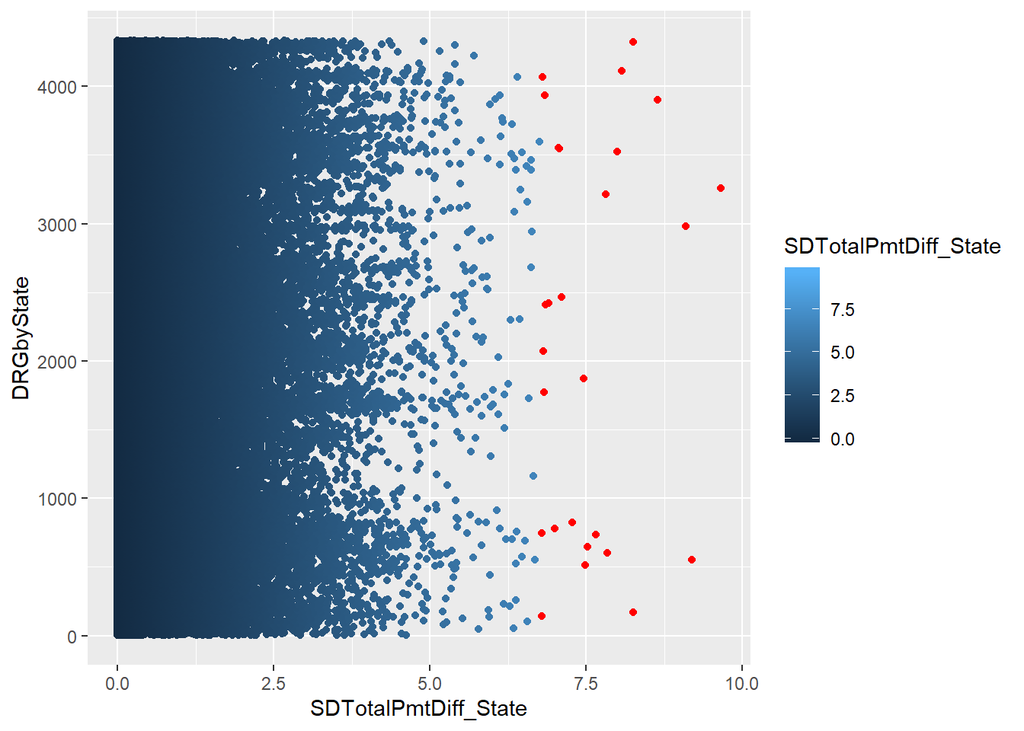

```r
payment <- as.data.table(payment)
df_outlier <- payment[payment$SDTotalPmtDiff_State > 0.70*(max(payment$SDTotalPmtDiff_State) - min(payment$SDTotalPmtDiff_State[payment$SDTotalPmtDiff_State> 0])),]
av1 <- payment[,SDTotalPmtDiff_State,by=DRGbyState]
ggplot(data = av1,mapping = aes(y = DRGbyState,x = SDTotalPmtDiff_State,colour=SDTotalPmtDiff_State))+
  geom_point() +
  geom_point(data=df_outlier, aes(x=SDTotalPmtDiff_State,y=DRGbyState), color='red',size=1.5)
```

#### 12 - Standard deviation between Total payment to the provider for a DRG and the mean of the Total payment to the Provider grouped by DRG-Zip combination

```r
payment <- as.data.frame(payment)
SDTotalPmt_Zip <- sqldf('select DRGbyZip, stdev("Average.Total.Payments") as SDTotalPmt_Zip from payment group by DRGbyZip')
payment <- merge(payment, SDTotalPmt_Zip)
payment$SDTotalPmt_Zip[is.na(payment$SDTotalPmt_Zip)] <- 0 #replacing NAs for single entries with 0s for SD
payment$SDTotalPmtDiff_Zip <- (payment$TotalPmtDiff_Zip/payment$SDTotalPmt_Zip)

#Replacing all NAs for single entries and negative values to 0s for SD as we are interested only in amount higher, not lesser than the mean
payment$SDTotalPmtDiff_Zip[is.na(payment$SDTotalPmtDiff_Zip)] <- 0
payment$SDTotalPmtDiff_Zip[payment$SDTotalPmtDiff_Zip < 0] <- 0
```

##### The following plot shows some outlying points which are DRG-Zip combos where the Standard Deviation of the Total payments to the provider are way higher than the mean of the Total payment to the Provider grouped by DRG-Zip combination. we’re interested in values higher than a specific set limit, say top 30% with really high deviations that may indicate providers involved in Upcoding and excessive unnecessary services

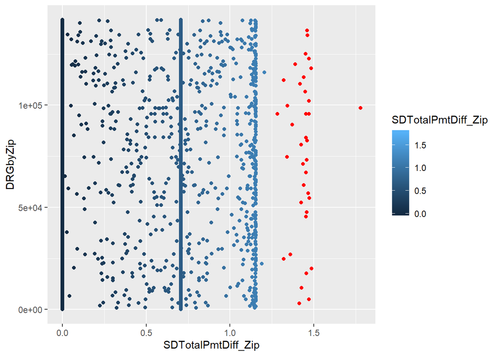

```r
payment <- as.data.table(payment)
df_outlier <- payment[payment$SDTotalPmtDiff_Zip > 0.70*(max(payment$SDTotalPmtDiff_Zip) - min(payment$SDTotalPmtDiff_Zip[payment$SDTotalPmtDiff_Zip> 0])),]
av1 <- payment[,SDTotalPmtDiff_Zip,by=DRGbyZip]
ggplot(data = av1,mapping = aes(y = DRGbyZip,x = SDTotalPmtDiff_Zip,colour=SDTotalPmtDiff_Zip))+
  geom_point() +
  geom_point(data=df_outlier, aes(x=SDTotalPmtDiff_Zip,y=DRGbyZip), color='red',size=1.5)
```

#### 13 - Standard deviation between Total payment to the provider for a DRG and the mean of the Total payment to the Provider grouped by DRG-Hospital Referral Region (HRR) combination

```r
payment <- as.data.frame(payment)
SDTotalPmt_HRR <- sqldf('select DRGbyHRR, stdev("Average.Total.Payments") as SDTotalPmt_HRR from payment group by DRGbyHRR')
payment <- merge(payment, SDTotalPmt_HRR)
payment$SDTotalPmt_HRR[is.na(payment$SDTotalPmt_HRR)] <- 0 #replacing NAs for single entries with 0s for SD
payment$SDTotalPmtDiff_HRR <- (payment$TotalPmtDiff_HRR/payment$SDTotalPmt_HRR)

#Replacing all NAs for single entries and negative values to 0s for SD as we are interested only in amount higher, not lesser than the mean
payment$SDTotalPmtDiff_HRR[is.na(payment$SDTotalPmtDiff_HRR)] <- 0
payment$SDTotalPmtDiff_HRR[payment$SDTotalPmtDiff_HRR < 0] <- 0
```

##### This feature provides us DRG-HRR combos where the Standard Deviation of the Total payments to the provider are way higher than the mean of the Total payment to the Provider grouped by DRG-HRR combination by setting outlier criteria, say top 30% with really high deviations that may indicate providers involved in Upcoding and excessive unnecessary services

#### 14 - Standard deviation between Average Covered Charges for a DRG and Mean Medicare Payments for every unique DRG-State combination

```r
payment <- as.data.frame(payment)
MeanTotalChrg_State <- sqldf('select DRGbyState, avg("Average.Covered.Charges") as MeanTotalChrg_State from payment group by DRGbyState')
payment <- merge(payment, MeanTotalChrg_State)
payment$TotalChrgDiff_State <- payment$Average.Covered.Charges - payment$MeanTotalChrg_State

SDTotalChrg_State <- sqldf('select DRGbyState, stdev("Average.Covered.Charges") as SDTotalChrg_State from payment group by DRGbyState')
payment <- merge(payment, SDTotalChrg_State)
payment$SDTotalChrg_State[is.na(payment$SDTotalChrg_State)] <- 0 #replacing NAs for single entries with 0s for SD
payment$SDTotalChrgDiff_State <- (payment$TotalChrgDiff_State/payment$SDTotalChrg_State)

#Replacing all NAs for single entries and negative values to 0s for SD as we are interested only in amount higher, not lesser than the mean
payment$SDTotalChrgDiff_State[is.na(payment$SDTotalChrgDiff_State)] <- 0
payment$SDTotalChrgDiff_State[payment$SDTotalChrgDiff_State < 0] <- 0
```

##### The following plot shows some outlying points which are DRG-State combos where the Standard Deviation of the Provider’s charges for a DRG are way higher than the mean of the difference between Average Covered Charges and Mean Medicare payments grouped by DRG-State combination we’re interested in values higher than a specific set limit, say top 30% with really high deviations that may indicate providers involved in billing for service with higher reimbursement rate

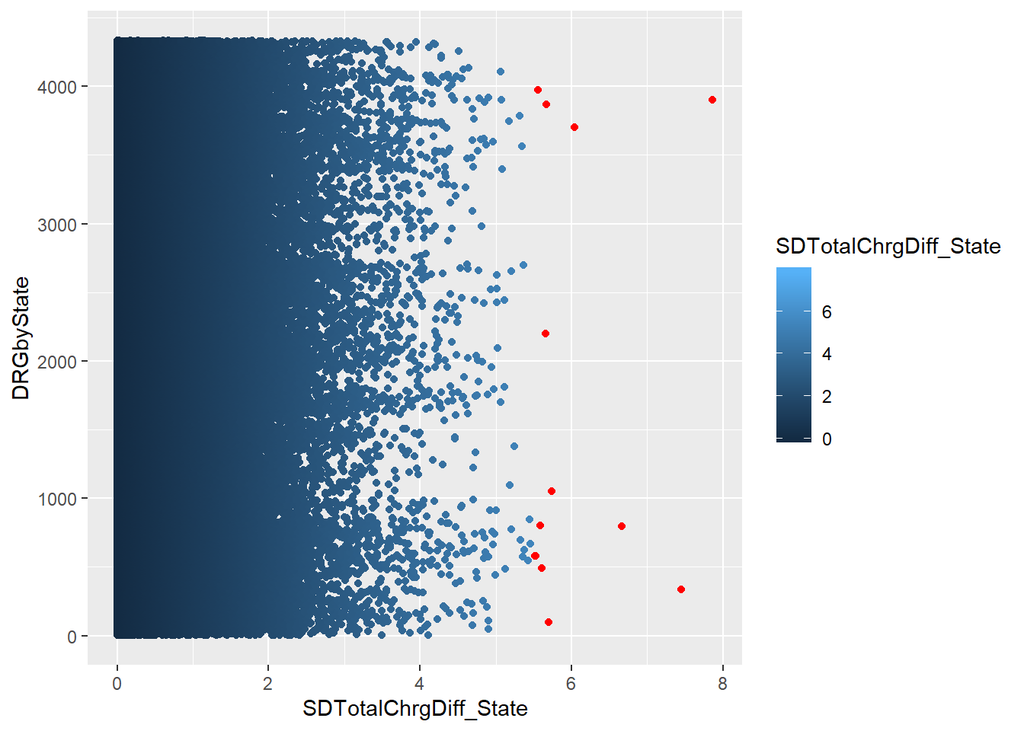

```r
payment <- as.data.table(payment)
df_outlier <- payment[payment$SDTotalChrgDiff_State > 0.70*(max(payment$SDTotalChrgDiff_State) - min(payment$SDTotalChrgDiff_State[payment$SDTotalChrgDiff_State> 0])),]
av1 <- payment[,SDTotalChrgDiff_State,by=DRGbyState]
ggplot(data = av1,mapping = aes(y = DRGbyState,x = SDTotalChrgDiff_State,colour=SDTotalChrgDiff_State))+
  geom_point() +
  geom_point(data=df_outlier, aes(x=SDTotalChrgDiff_State,y=DRGbyState), color='red',size=1.5)
```

#### 15 - Standard deviation between Average Covered Charges for a DRG and Mean Medicare Payments for every unique DRG-Zip combination

```r
payment <- as.data.frame(payment)

MeanTotalChrg_Zip <- sqldf('select DRGbyZip, avg("Average.Covered.Charges") as MeanTotalChrg_Zip from payment group by DRGbyZip')
payment <- merge(payment, MeanTotalChrg_Zip)
payment$TotalChrgDiff_Zip <- payment$Average.Covered.Charges - payment$MeanTotalChrg_Zip
SDTotalChrg_Zip <- sqldf('select DRGbyZip, stdev("Average.Covered.Charges") as SDTotalChrg_Zip from payment group by DRGbyZip')
payment <- merge(payment, SDTotalChrg_Zip)
payment$SDTotalChrg_Zip[is.na(payment$SDTotalChrg_Zip)] <- 0 #replacing NAs for single entries with 0s for SD
payment$SDTotalChrgDiff_Zip <- (payment$TotalChrgDiff_Zip/payment$SDTotalChrg_Zip)

#Replacing all NAs for single entries and negative values to 0s for SD as we are interested only in amount higher, not lesser than the mean
payment$SDTotalChrgDiff_Zip[is.na(payment$SDTotalChrgDiff_Zip)] <- 0
payment$SDTotalChrgDiff_Zip[payment$SDTotalChrgDiff_Zip < 0] <- 0
```

##### The following plot shows some outlying points which are DRG-Zip combos where the Standard Deviation of the Provider’s charges for a DRG are way higher than the mean of the difference between Average Covered Charges and Mean Medicare payments grouped by DRG-Zip combination we’re interested in values higher than a specific set limit, say top 30% with really high deviations that may indicate providers involved in billing for service with higher reimbursement rate

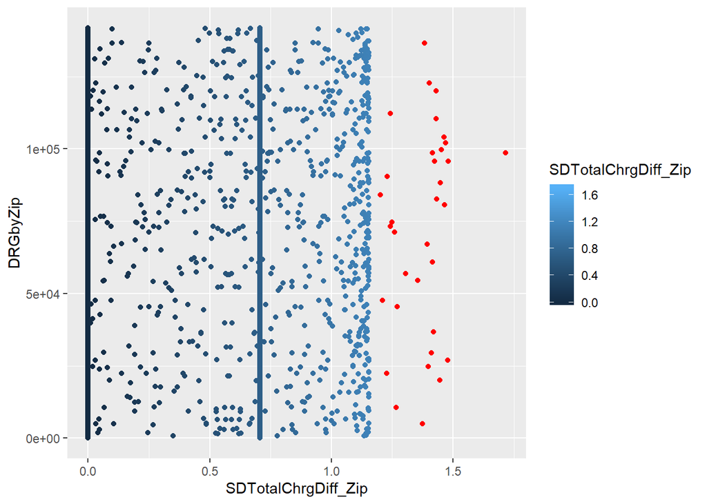

```r
payment <- as.data.table(payment)
df_outlier <- payment[payment$SDTotalChrgDiff_Zip > 0.70*(max(payment$SDTotalChrgDiff_Zip) - min(payment$SDTotalChrgDiff_Zip[payment$SDTotalChrgDiff_Zip> 0])),]
av1 <- payment[,SDTotalChrgDiff_Zip,by=DRGbyZip]
ggplot(data = av1,mapping = aes(y = DRGbyZip,x = SDTotalChrgDiff_Zip,colour=SDTotalChrgDiff_Zip))+
  geom_point() +
  geom_point(data=df_outlier, aes(x=SDTotalChrgDiff_Zip,y=DRGbyZip), color='red',size=1.5)
```

#### 16 - Standard deviation between Average Covered Charges for a DRG and Mean Medicare Payments for every unique DRG-HRR (Hospital Referral Region) combination

```r
payment <- as.data.frame(payment)
MeanTotalChrg_HRR <- sqldf('select DRGbyHRR, avg("Average.Covered.Charges") as MeanTotalChrg_HRR from payment group by DRGbyHRR')
payment <- merge(payment, MeanTotalChrg_HRR)
payment$TotalChrgDiff_HRR <- payment$Average.Covered.Charges - payment$MeanTotalChrg_HRR
SDTotalChrg_HRR <- sqldf('select DRGbyHRR, stdev("Average.Covered.Charges") as SDTotalChrg_HRR from payment group by DRGbyHRR')
payment <- merge(payment, SDTotalChrg_HRR)
payment$SDTotalChrg_HRR[is.na(payment$SDTotalChrg_HRR)] <- 0 #replacing NAs for single entries with 0s for SD
payment$SDTotalChrgDiff_HRR <- (payment$TotalChrgDiff_HRR/payment$SDTotalChrg_HRR)

#Replacing all NAs for single entries and negative values to 0s for SD as we are interested only in amount higher, not lesser than the mean
payment$SDTotalChrgDiff_HRR[is.na(payment$SDTotalChrgDiff_HRR)] <- 0
payment$SDTotalChrgDiff_HRR[payment$SDTotalChrgDiff_HRR < 0] <- 0
```

##### This feature provides us DRG-HRR combos where the Standard Deviation of the Provider’s charges for a DRG are way higher than the mean of the difference between Average Covered Charges and Mean Medicare payments grouped by DRG-HRR combination by setting outlier criteria, say top 30% with really high deviations that may indicate providers involved in billing for service with higher reimbursement rate

##### Preview of the dataframe after post feature engineering

```r
tail(payment,10)
```

```
##        DRGbyHRR DRGbyZip DRGbyState Provider.Zip.Code
## 149808    27439   140537       4332             25550
## 149809    27439   140539       4332             25701
## 149810    27439   140539       4332             25701
## 149811    27439   140929       4306             41101
## 149812    27439   140929       4306             41101
## 149813    27440   140543       4332             26241
## 149814    27440   140546       4332             26506
## 149815    27440   140545       4332             26505
## 149816    27440   140544       4332             26330
## 149817    27441   141590       4333             82601
##                        DRG.Definition Provider.Id
## 149808 948 - SIGNS & SYMPTOMS W/O MCC      510012
## 149809 948 - SIGNS & SYMPTOMS W/O MCC      510055
## 149810 948 - SIGNS & SYMPTOMS W/O MCC      510007
```

[output cut: 183 more lines]

### CONCLUSION

#### 1. Features 8,9,10 related to the ratio of discharges between DRG-Provider combination and total discharges at a State, Zipcode and HRR level respectively can help provide us outlier information on how patients from the same location are potentially targeted by provider groups as per Level 6 of Healthcare Fraud Control as defined by Sparrow M. K. (2000)

#### 2. The remaining features that are derived based on the differences and deviations of charges and payments related to every DRG at a State, Zip and HRR level relative to the mean values can provide us information on the following potential healthcare frauds:

#### a. Upcoding - Billing for a service with a higher reimbursement rate than the service provided

#### b. Excessive or Unnecessary Services - Provides medically excessive or unnecessary services to a patient

#### 3. The cut-off for the outliers will need to be set for every feature with its own criteria based on judgements from interviews with experts to focus on potential cases of fraud